# Introdução a modelos lineares mistos para os estudos da linguagem (aula 2)

Mahayana C. Godoy (PPgEL/UFRN)

16/11/2019

> **Para citar este material:**

> Godoy, M. C. (2019). Introdução aos modelos lineares mistos para os estudos da linguagem. PsyArXiv. https://doi.org/10.17605/OSF.IO/9T8UR

## 2. Modelos Lineares

Modelos lineares mistos são, por definição, modelos lineares. Por isso, é importante entendermos primeiro o que é um modelo linear. Nesta seção, vamos apresentar alguns conceitos básicos.

1. Sintaxe do modelo linear no R
2. Interceptos e slopes
3. Equação da regressão linear
4. Hipóteses de um modelo linear

Enquanto você acompanha a parte introdutória do tutorial, baixe os novos pacotes que serão usados para as atividades e carregue os pacotes que serão usados:

```r
#instalar pacote novo para a seção

install.packages("yarrr")

#carregar pacotes

library(ggplot2)
library(dplyr)
```

## 2.1 Modelos lineares: sintaxe em R e conceitos básicos

Para demonstrar o que é um modelo linear, seguiremos uma adaptação do tutorial de Bodo Winter (2013), usando o mesmo conjunto de dados e mudando um pouco a ordem de apresentação dos argumentos.

Começaremos criando o mesmo conjunto de dados que Winter cria para responder a seguinte pergunta: a idade de uma pessoa prevê o seu pitch?

```r
# Criar conjunto de dados de Winter (2013)

## criando vetor idade
idade = c(14,23,35,48,52,67)

##criando vetor pitch
pitch = c(252,244,240,233,212,204)

## combinando os dois vetores em um dataframe
my.df = data.frame(idade,pitch)

## vendo o dataframe

head(my.df)
```

```
#>   idade pitch
#> 1    14   252
#> 2    23   244
#> 3    35   240
#> 4    48   233
#> 5    52   212
#> 6    67   204
```

Ao olharmos o conjunto de dados que criamos, percebemos que as pessoas mais novas parecem ter um pitch mais alto. Na verdade, podemos representar cada indivíduo em um gráfico como na **Figura 2.1**, e isso nos mostrará que (a) parece haver uma relação entre idade e pitch; (b) essa relação pode ser modelada por uma linha reta.

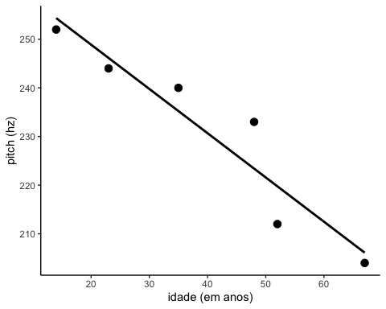

**Figura 2.1**: relação entre pitch e idade

Ao ver o gráfico acima, é possível nos perguntarmos se *pitch muda em função de idade*.

Um modelo linear é uma maneira matemática de avaliar se pitch e idade se relacionam de alguma maneira. Para isso, vamos expressar em uma fórmula simples a relação entre as duas variáveis que estamos estudando.

> pitch ~ idade

A fórmula acima pode ser lida como *pitch em função de idade*. Você já deve ter visto esses termos sendo chamados de *variável dependente* (o pitch, aquilo que medimos) e *variável independente* (a idade, aquilo que acreditamos que terá um efeito ou que se correlaciona de alguma maneira com a variável dependente). Também é possível chamar essas duas variáveis de **variável resposta** e **variável preditora**, respectivamente, em uma relação mais causal. Aqui, chamaremos a variável independente de **efeito fixo**, por motivos que ficarão claros mais adiante.

É possível que haja uma relação entre pitch e idade, mas as coisas não são tão determinísticas assim. O pitch pode ser influenciado por outros aspectos, e a mesma pessoa pode ver seu pitch mudar a depender de fatores como estado emocional, disposição, doenças que afetem as vias respiratórias etc. Nossa fórmula é então reescrita com a adição de um termo que capte esses fatores aleatórios. Na formula abaixo, $\epsilon$ representa todo o ruído que afeta pitch e que não foi controlado no experimento.

> pitch ~ idade + $\epsilon$

Para criar um modelo linear no R, usamos a função `lm()` e escrevemos a equação desejada como seu argumento.

Abaixo, criamos o objeto `modelo.idade`, que corresponde a um modelo linear que toma pitch em função de idade a partir do conjunto de dados `my.df`.

```r
## Criando um modelo linear de pitch em função de idade

modelo.idade = lm(pitch ~ idade, my.df)
```

Podemos usar a função `names()` para ver os dados contidos dentro de `modelo.idade`. Na sequência, vemos o conteúdo de `fitted.values` e `residuals`

```r
## ver os nomes dos objetos contidos no objeto modelo.idade

names(modelo.idade)
```

```
#>  [1] "coefficients"  "residuals"     "effects"       "rank"
#>  [5] "fitted.values" "assign"        "qr"            "df.residual"
#>  [9] "xlevels"       "call"          "terms"         "model"
```

```r
## ver o que há em fitted.values

modelo.idade$fitted.values
```

```
#>        1        2        3        4        5        6
#> 254.3383 246.1495 235.2310 223.4027 219.7633 206.1152
```

```r
## ver o que há em residuals

modelo.idade$residuals
```

```
#>         1         2         3         4         5         6
#> -2.338293 -2.149468  4.768965  9.597267 -7.763256 -2.115215
```

Os valores de `fitted.values`, **ou valores ajustados**, são os valores previstos pela reta, e os valores residuais são a diferença entre o valor ajustado e o valor observado. Na **Figura 2.2**, os resíduos são representados pela linha que liga valor observado (pontos pretos) e valor ajustado (pontos brancos).

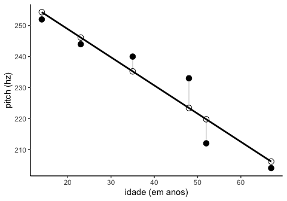

**Figura 2.2:** relação entre pitch e idade

Para saber o resultado do modelo linear, usamos a função `summary()`.

```r
# buscando o sumário dos valores do modelo linear

summary(modelo.idade)
```

```
#>
#> Call:
#> lm(formula = pitch ~ idade, data = my.df)
#>
#> Residuals:
#>      1      2      3      4      5      6
#> -2.338 -2.149  4.769  9.597 -7.763 -2.115
#>
#> Coefficients:
#>             Estimate Std. Error t value Pr(>|t|)
#> (Intercept) 267.0765     6.8522   38.98 2.59e-06 ***
#> idade        -0.9099     0.1569   -5.80  0.00439 **
#> ---
#> Signif. codes:  0 '***' 0.001 '**' 0.01 '*' 0.05 '.' 0.1 ' ' 1
#>
#> Residual standard error: 6.886 on 4 degrees of freedom
#> Multiple R-squared:  0.8937, Adjusted R-squared:  0.8672
#> F-statistic: 33.64 on 1 and 4 DF,  p-value: 0.004395
```

De início, podemos reconhecer duas informações que já sabemos sobre o modelo:

- `call`: a fórmula usada no modelo
- `residual`: os resíduos do modelo

Além disso, há uma seção chamada `coefficients`, mas deixaremos isso para depois.

Dando sequência, vemos no rodapé uma série de informações do modelo como um todo. O $R^2$ (ou **R ao quadrado**) é uma medida que vai de 0 a 1 indica a variância explicada pelo modelo. O valor de 0.89 indica que nosso modelo é capaz de explicar 89% do que está acontecendo no nosso conjunto de dados. Como temos apenas um efeito fixo em `modelo.idade`, podemos entender o $R^2$ como indicativo da variância explicada pela idade.

Como Winter (2013) aponta, o que é um valor alto de $R^2$ varia de área para área e depende do problema estudado. Em contextos em que o efeito estudado é muito complexo, é mais comum lidarmos com valores mais baixos.

O **valor ajustado de R** (*Adjusted R-squared*) é um valor relacionado ao $R^2$, mas que leva em conta o número de efeitos fixos inseridos no modelo. Porque só há um efeito fixo em `modelo.idade`, os valores são bem similares, mas o valor ajustado seria menor se o modelo tivesse mais efeitos fixos.

Mais adiante, você encontra o **p-valor** associado ao modelo. Para explicá-lo, recorremos ao que diz Winter (2013) em seu tutorial.

> “Uma maneira de colocar seria dizer que, assumindo que seu modelo não esteja fazendo nada, a probabilidade dos seus dados é muito baixa (porque o p-valor é pequeno nesse caso). Tecnicamente, o p-vaor é uma probabilidade condicional, é a probabilidade sob a condição de que a hipótese nula seja verdadeira.” (Winter, B. 2013, p. 5)

No caso que estamos avaliando aqui, a hipótese nula é “idade não tem qualquer efeito em pitch”, e uma hipótese alternativa seria “idade tem efeito em pitch”.

> “[O] modelo linear mostra que se essa hipótese [nula] é verdadeira, então nossos dados são muito improváveis. Isso é imterpretado como indicativo de que a hipótese alternativa (…) é mais provável e que, portanto, nosso resultado é estatisticamente significativo.” (Winter, B. 2013, p. 5)

Não podemos confundir o p-valor do modelo completo com o p-valor dos coeficientes dos efeitos fixos (que costumam ser mais interessantes quando fazemos uma análise com modelos mistos, mas falaremos sobre isso em outro momento).

## 2.2 Os coeficientes do modelo linear

Quando ajustamos um modelo linear, geralmente estamos mais interessados nos coeficientes dos seus efeitos fixos. Abaixo buscamos novamente o sumário dos resultados para análisar seus coeficientes. Achamos essa informação logo abaixo dos resíduos.

```r
# buscando o sumário dos valores do modelo linear

summary(modelo.idade)
```

```
#>
#> Call:
#> lm(formula = pitch ~ idade, data = my.df)
#>
#> Residuals:
#>      1      2      3      4      5      6
#> -2.338 -2.149  4.769  9.597 -7.763 -2.115
#>
#> Coefficients:
#>             Estimate Std. Error t value Pr(>|t|)
#> (Intercept) 267.0765     6.8522   38.98 2.59e-06 ***
#> idade        -0.9099     0.1569   -5.80  0.00439 **
#> ---
#> Signif. codes:  0 '***' 0.001 '**' 0.01 '*' 0.05 '.' 0.1 ' ' 1
#>
#> Residual standard error: 6.886 on 4 degrees of freedom
#> Multiple R-squared:  0.8937, Adjusted R-squared:  0.8672
#> F-statistic: 33.64 on 1 and 4 DF,  p-value: 0.004395
```

Perceba que são atribuídos coeficientes para duas linhas diferentes: *intercept* e *idade*. Comecemos pelo primeiro.

O valor de **intercept** em um modelo linear, será o valor em que a reta ajustada pelo modelo **intercepta** o eixo y quando o valor de x (o efeito fixo) é igual a zero. No caso do modelo ajustado, nosso efeito fixo é *idade*. O valor estimado para o *intercept* - ou **intercepto**, como iremos chamá-lo daqui em diante - é de 267.07, o que indica o pitch estimado de uma pessoa aos 0 anos de idade. Dito de outro modo, se voltarmos na Figura 2.1 e continuarmos traçando a reta, ela cruzaria o eixo y no valor de 267.07.

Claro que esse intercepto não faz muito sentido, pois não há como uma pessoa não nascida (i.e., com 0 anos) ter pitch. Cabe a você interpretar quão informativo é o intercepto para o modelo ajustado.

Em todo caso, entender o que é o intercepto nos ajuda a compreender o que significa o valor atribuído ao efeito fixo *idade*. Vemos que é um valor negativo, de -0.9099. Isso indica que para cada unidade que você “anda” à direita no eixo x, o valor e y recebe um decréscimo de 0.9099: dito de outro modo, para cada unidade de x, a reta tem um **declive** (ou **slope**, em inglês) de -0.9099. Lembremos que nosso eixo x indica idade, e o eixo y indica o valor de pitch em hertz. Para usar o termo em inglês, o **slope** estimado de idade indica que, para cada ano de vida, o modelo prevê uma queda em hertz de 0.9099. Assim, o modelo prevê que uma criança de um ano teria um pitch de 267.07 (o valor do intercepto) *menos* 0.9099. Podemos escrever da seguinte maneira

```r
# pessoa com um ano

267.0765 - 0.9099
```

```
#> [1] 266.1666
```

```r
# pessoa com dois anos

267.0765 - (0.9099*2)
```

```
#> [1] 265.2567
```

```r
# pessoa com três anos

267.0765 - (0.9099*3)
```

```
#> [1] 264.3468
```

```r
# pessoa com quatorze anos

267.0765 - (0.9099*14)
```

```
#> [1] 254.3379
```

```r
# buscando os valores ajustados no modelo (primeiro dado corresponde a indivíduo de 14 anos)

modelo.idade$fitted
```

```
#>        1        2        3        4        5        6
#> 254.3383 246.1495 235.2310 223.4027 219.7633 206.1152
```

Perceba que o valor de pitch que calculamos para uma pessoa de 14 anos é justamente o valor previsto quando pedimos para ver os valores ajustados!

Agora estamos um pouco mais equipados para entender o que um modelo linar faz. Primeiro, convém mencionar que o valor estimado dos coeficientes é chamdo de *beta*, frequentemente representado pela letra grega $\beta$. O coeficiente do intercepto é representado por $\beta_{0}$.

Um modelo linear ajusta uma reta a um plano cartesiano, e os valores previstos por essa reta são previstos pela equação abaixo:

**Para regressão com uma variável**

$y=\beta_{0}+\beta_{1}x_{1}$

**Para regressão com $n$ variáveis**

$y=\beta_{0}+\beta_{1}x_{1}+\beta_{2}x_{2}+...\beta_{n}x_{n}$

Voltaremos a essa equação em outro momento.

Ao analisar os coeficientes do modelo, vemos que o **p-valor associado a *idade*** é igual ao p-valor do modelo como um todo: 0.0043. Isso ocorre porque nosso modelo tem apenas um efeito fixo, e portanto a significância do modelo será equivalente a quão significante é esse efeito fixo. Se nosso modelo tivesse mais um efeito fixo (sexo, por exemplo), haveria um p-valor para o modelo (que indicaria a significância do modelo como um todo) com valor diferente do p-valor de idade (que indica a significância da variável idade em definir os valores de y, isto é, de pitch).

O p-valor de 0.0043 nos indica, portanto, que é muito pouco provável a hipótese nula de que *idade* não tem um efeito sobre o pitch de uma pessoa.

## 2.3 Modelos lineares com efeitos fixos categóricos

Até agora, vimos apenas casos em que o efeito fixo é uma variável numérica, mas frequentemente lidamos com variáveis categóricas como gênero, profissão, grau de escolaridade, dialeto etc. A vantagem de trabalhar com modelos lineares é que é possível analisar esses dados da mesma maneira que já vimos anteriormente.

Consideremos um novo conjunto de dados, também criado por Winter (2013). Dessa vez, queremos saber se o pitch de uma pessoa muda em função de seu sexo.

```r
#Criando dataframe para testar se pitch ~ sexo

## vetor com dados de pitch
pitch = c(233,204,242,130,112,142)


## vetor com dados de sexo
sexo = c(rep("feminino",3),rep("masculino",3))

## combinando os dois vetores em um dataframe
my.df2 = data.frame(sexo,pitch)

## vendo o dataframe

head(my.df2)
```

```
#>        sexo pitch
#> 1  feminino   233
#> 2  feminino   204
#> 3  feminino   242
#> 4 masculino   130
#> 5 masculino   112
#> 6 masculino   142
```

Como antes, expressamos a hipótese a ser testada no modelo com a mesma equação:

> pitch ~ sexo + $\epsilon$

A implementação no R é exatamente a mesma, mas você pode ver que a leitura dos coeficientes vai ser um pouco diferente.

```r
# ajustar o modelo

modelo.sexo = lm(pitch ~ sexo, my.df2)

# resultados

summary(modelo.sexo)
```

```
#>
#> Call:
#> lm(formula = pitch ~ sexo, data = my.df2)
#>
#> Residuals:
#>       1       2       3       4       5       6
#>   6.667 -22.333  15.667   2.000 -16.000  14.000
#>
#> Coefficients:
#>               Estimate Std. Error t value Pr(>|t|)
#> (Intercept)     226.33      10.18  22.224 2.43e-05 ***
#> sexomasculino   -98.33      14.40  -6.827  0.00241 **
#> ---
#> Signif. codes:  0 '***' 0.001 '**' 0.01 '*' 0.05 '.' 0.1 ' ' 1
#>
#> Residual standard error: 17.64 on 4 degrees of freedom
#> Multiple R-squared:  0.921,  Adjusted R-squared:  0.9012
#> F-statistic: 46.61 on 1 and 4 DF,  p-value: 0.002407
```

Já sabemos interpretar os valores de $R^2$ e R ajustado, bem como o p-valor do modelo, que é de 0.002. Não há nada de diferente aqui. Vemos, inclusive, que o p-valor do modelo é igual ao p-valor do coeficiente do efeito fixo, já que, por ser um modelo de apenas um efeito fixo, a significância do modelo e do efeito fixo é a mesma.

No entanto, a linha do efeito fixo na tabela de coeficientes diz apenas `sexomasculino`. Para onde foi o feminino? O que isso quer dizer? Para responder a essas perguntas, vamos usar o dplyr para extrair as médias de pitch para os indivíduos do sexo masculino e feminino.

```r
## médias de pitch por sexo

my.df2%>%
  group_by(sexo)%>%
  summarize(mean(pitch))
```

```
#> # A tibble: 2 x 2
#>   sexo      `mean(pitch)`
#>   <fct>             <dbl>
#> 1 feminino           226.
#> 2 masculino          128
```

Se você comparar as médias com os coeficientes, perceberá que o **intercepto** corresponde à média de pitch dos participantes do sexo feminino, o que significa que o modelo tomou o níve *feminino* como **nível de referência**. É por isso que esse nível não aparece na tabela de coeficientes: ele está “disfarçado” como o intercepto do modelo.

E a linha correspondente a `sexomasculino`? Vemos que ela tem o valor de $\beta$ igual a -98.33, que em nada se parece com a média dos indivíduos do sexo masculino, que foi de 128hz. No entanto, vemos que esse é exatamente a diferença entre a média masculina e a feminina:

> média feminina - $\beta$ = média masculina

> 226.33 - 98.33 = 128

Para entender melhor o que está acontecendo aqui, vamos dar uma olhada na **Figura 2.3**, que mostra a distribuição dos dados. Lembremos também que um modelo linear tenta ajustar retas que expliquem essa distribuição.

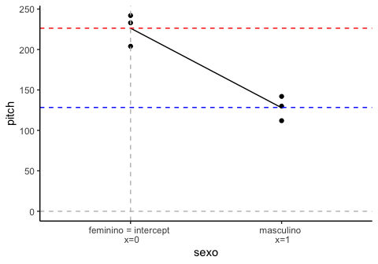

**Figura 2.3**: pitch em função de sexo

Vimos que o valor médio do nível feminino foi tomado como intercepto do modelo. Por esse motivo, indicamos no gráfico que o nível feminino tem o valor de x igual a zero. Vemos também, na linha tracejada vermelha, que esse valor é de 226.33.

Para irmos ao valor médio de *masculino*, que está em x = 1, nossa reta tem que descer 98.33hz: o seu **slope** é de -98.33. Vemos que, quando x = 1, o valor médio de pitch é 128hz, representado pela linha tracejada azul.

Isso não é diferente do que vimos antes: o modelo assume um intercepto para y quando x = 0, e então indica o **slope** que mostra a diferença entre esse intercepto e as outra unidade da variável em x.

Você pode se perguntar o porquê de o feminino - e não o masculino - ter sido tomado como nível de referência. Isso ocorre porque o R organiza os níveis de uma variável categórica em ordem alfabética. Você pode escolher o seu nível de referência (que será o seu intercepto) com a função `relevel()`.

```r
# sobrescrever a coluna sexo com um novo nível de referência

my.df2$sexo = relevel(my.df2$sexo, ref = "masculino")

# ajustar o modelo

modelo.sexo2 = lm(pitch ~ sexo, my.df2)

# resultados

summary(modelo.sexo2)
```

```
#>
#> Call:
#> lm(formula = pitch ~ sexo, data = my.df2)
#>
#> Residuals:
#>       1       2       3       4       5       6
#>   6.667 -22.333  15.667   2.000 -16.000  14.000
#>
#> Coefficients:
#>              Estimate Std. Error t value Pr(>|t|)
#> (Intercept)    128.00      10.18  12.568 0.000231 ***
#> sexofeminino    98.33      14.40   6.827 0.002407 **
#> ---
#> Signif. codes:  0 '***' 0.001 '**' 0.01 '*' 0.05 '.' 0.1 ' ' 1
#>
#> Residual standard error: 17.64 on 4 degrees of freedom
#> Multiple R-squared:  0.921,  Adjusted R-squared:  0.9012
#> F-statistic: 46.61 on 1 and 4 DF,  p-value: 0.002407
```

Acima, usamos essa função para informar que desejamos que *masculino* seja o nível de referência. Você verá que o resultado no modelo permanecerá quase inalterado, exceto por dois detalhes: o nome da linha do coeficiente de efeito fixo - que agora passar a ser `sexofeminino` e o sinal do valor do coeficiente estimado, que será positivo. Isso ocorre porque agora a nossa reta precisa subir 98hz, e não descer, como vemos na **Figura 2.4**.

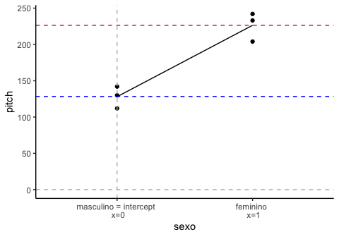

**Figura 2.4:** pitch em função de sexo, com masculino como intercept

Voltemos ao nosso modelo original, em que masculino = 1 e feminino = 0 e vamos olhar novamente a equação do modelo linear.

**Relembrando cálculo de y na regressão com uma variável**

$y=\beta_{0}+\beta_{1}x_{1}$

Se quisermos calcular o valor de `y` para masculino (o nosso $x_1$), podemos substituir essa equação pelo valores obtidos em nosso modelo linear:

$\beta_{0}$ = 226.33

$\beta_{1}$ = -98.33

$x_1$ = 1

> y = 226.33 + (-98.33*1) = 128

Desse modo, percebemos que aqui também a distribuição de dados está sendo modelada a partir da equação de uma regressão linear.

Entender que o modelo está lendo o o nível de referência como igual a 0 e o nível ao qual está fazendo a comparação como igual a 1 será útil quando discutirmos **contrastes** na seção 4.

## 2.4 Modelos lineares e outros testes estatísticos

Se você conhece um pouco de estatística, deve estar pensando que os problemas que vimos até aqui poderiam ser resolvidos por um teste de correlação (no caso de picth ~ idade) e por um teste-t ou ANOVA (no caso de pitch ~ sexo).

De fato, isso é verdade, e se você fizer essa análise verá que os valores do p-valor para o modelo serão os mesmos. Isso ocorre porque todos esses testes *são* modelos lineares.

A vantagem do modelo linear e do uso de retas para mostrar diferenças entre dois níveis de uma variável categórica ficará mais clara ao discutirmos as vantagens do modelo linear misto na próxima seção.

## 2.5 Modelos lineares com mais de uma variável

Até agora, vimos modelos bastante simples, mas podemos torná-los mais complexo. O pitch de uma pessoa é modelado tanto por seu sexo quanto por sua idade. É possível colocar os dois efeitos no modelo. Adicionalmente, podemos também colocar a língua que ela fala, para testar se esse fator influencia o pitch.

> pitch ~ sexo + idade + língua

Nesse caso, a análise de resultados será bastante similar. A diferença principal será o p-valor do modelo, que será diferente do p-valor daqueles apresentados para cada um dos efeitos fixos.

Para ilustrar, consideremos o conjunto de dados `diamonds`, do pacote `yarrr`. Se você já baixou e carregou esse pacote, esse conjunto de dados já está disponível para inspeção.

```r
## conhecendo o conjunto de dados

head(diamonds)
```

```
#>   weight clarity color value
#> 1   9.35    0.88     4 182.5
#> 2  11.10    1.05     5 191.2
#> 3   8.65    0.85     6 175.7
#> 4  10.43    1.15     5 195.2
#> 5  10.62    0.92     5 181.6
#> 6  12.35    0.44     4 182.9
```

```r
## conhecendo o conjunto de dados

str(diamonds)
```

```
#> 'data.frame':    150 obs. of  4 variables:
#>  $ weight : num  9.35 11.1 8.65 10.43 10.62 ...
#>  $ clarity: num  0.88 1.05 0.85 1.15 0.92 0.44 1.09 1.43 0.95 1.05 ...
#>  $ color  : num  4 5 6 5 5 4 6 4 6 5 ...
#>  $ value  : num  182 191 176 195 182 ...
```

O pacote traz informações sobre 150 diamantes em 4 colunas:

- `weight`: informação sobre o peso do diamante
- `clarity`: informação sobre a claridade do diamante
- `color`: cor do diamente (uma variável categórica)
- `value`: preço de venda do diamante

Queremos saber se peso e claridade influenciam o preço de venda de diamante (idealmente faríamos alguns gráficos antes das análises, mas teremos tempo para treinar isso nas próximas seções).

```r
## construindo o modelo

modelo.diamonds = lm(value ~ weight + clarity, data = diamonds)

## resultados

summary(modelo.diamonds)
```

```
#>
#> Call:
#> lm(formula = value ~ weight + clarity, data = diamonds)
#>
#> Residuals:
#>     Min      1Q  Median      3Q     Max
#> -10.034  -3.802  -0.196   3.207  11.166
#>
#> Coefficients:
#>             Estimate Std. Error t value Pr(>|t|)
#> (Intercept)  145.446      2.795   52.04   <2e-16 ***
#> weight         2.219      0.199   11.15   <2e-16 ***
#> clarity       22.036      2.129   10.35   <2e-16 ***
#> ---
#> Signif. codes:  0 '***' 0.001 '**' 0.01 '*' 0.05 '.' 0.1 ' ' 1
#>
#> Residual standard error: 4.681 on 147 degrees of freedom
#> Multiple R-squared:  0.6334, Adjusted R-squared:  0.6284
#> F-statistic:   127 on 2 and 147 DF,  p-value: < 2.2e-16
```

Em primeiro lugar, vemos que o modelo foi significativo, como indica seu p-valor. Na tabela de coeficientes, vemos que o intercepto (o valor de venda quando peso e claridade são iguais a zero, o que não faz sentido) é igual a 145.5. Vemos que tanto claridade quanto peso influenciam de modo significativo o preço do diamante, e pelo valor positivo de seus coeficientes (2.219 e 22.036), sabemos que quanto maior o valor de peso e claridade, maior o preço de venda.

O primeiro diamante de nossa tabela tem um peso de 9.35 e uma claridade de 0.88. Através desses valores e da equação de regressão linear que já conhecemos, podemos calcular o preço previsto para esse diamante:

$y=\beta_{0}+\beta_{1}x_{1}+\beta_2x_2$

```r
# calculando valor estimado para o primeiro diamante da tabela

y = 145.446 + (2.219*9.35) + (22.036*0.88)

y
```

```
#> [1] 185.5853
```

Se olharmos pedirmos para ver os valores ajustados pelo modelo, veremos que esse foi o valor previsto para esse diamante (e que foi próximo do valor real de 182.5).

```r
## valores ajustados do modelo

head(modelo.diamonds$fitted.values)
```

```
#>        1        2        3        4        5        6
#> 185.5819 193.2105 183.3678 193.9277 189.2809 182.5417
```

## 2.6 Hipóteses do modelo

Um modelo linear assume uma série de hipóteses sobre os dados (*assumptions*, em inglês) que devem ser respeitadas para que seus resultados sejam confiáveis. Winter (2013) cita algumas das hipóteses que discutimos abaixo. Se você ainda não entedê-las com a explicação que segue, consulte o material do autor.

**Linearidade**

A primeira hipótese do modelo linear é bem óbvia: é possível explicar os dados por meio de relações lineares. Se essa relação não for linear, ao plotar os resíduos do modelo contra os valores ajustados, você verá algum outro padrão, como uma curva.

Vamos pegar os valores ajustados e os resíduos do último modelo que fizemos e transformarmos em um *dataframe*. Depois, vamos plotar um valor contra o outro em um gráfico de dispersão.

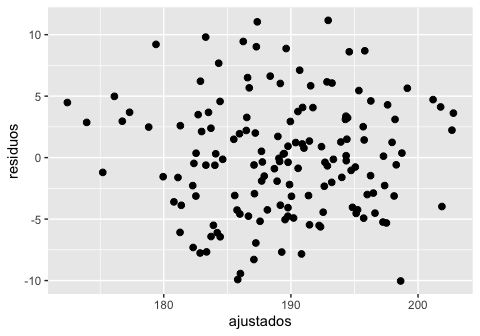

```r
# dataframe com os resíduos e fitted values do modelo

ajustados = modelo.diamonds$fitted.values
residuos = modelo.diamonds$residuals

aj.residuos = data.frame(ajustados, residuos)

# analisando os resíduos

ggplot(aj.residuos, aes(x = ajustados, y = residuos))+
  geom_point(size=2)
```

Quando o valor do resíduo é zero, é sinal que o valor previsto pelo modelo foi o valor observado. Vemos no gráfico acima que os valores dos resíduos circundam uma reta que poderíamos traçar no valor 0 do eixo y. Isso indica uma relação linear entre as variáveis. Uma relação não-linear geraria um gráfico tipo o que vemos abaixo.

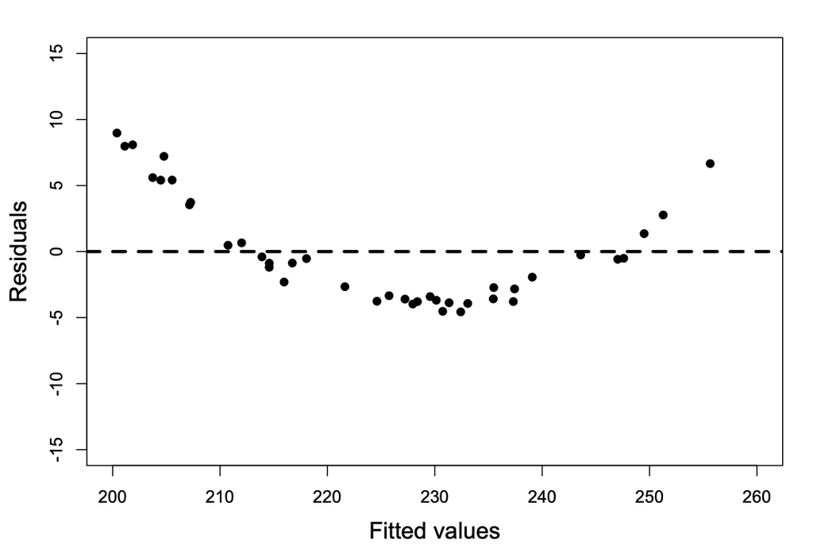

**Homocedasticidade**

Essa hipótese assume que a variância dos resíduos deve ser mais ou menos homogênea para os valores ajustados; ou seja, os resíduos devem variar ao longo do valor previsto de manaeira homogênera sem demonstrar tendências. É o caso do gráfico que fizemos anteriormente, e que mostra os valores residuais homogeneamente espalhados ao redor da linha que cortaria o valor zero no eixo y.

Um exemplo de resíduos que descumprem essa hipótese pode ser visto no gráfico abaixo. Perceba que os pontos não estão homogeneamente espalhados. Há maior concentração em determinados pontos, principalmente próximos da coordenada (0,0), e a dispersão se dá de forma heterogênea.

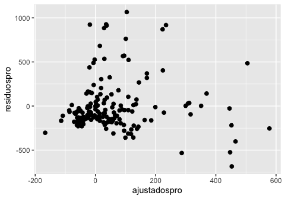

**Figura 2.6:** Gráficos de resíduos violando a hipótese de homocedasticidade

**Normalidade dos resíduos**

Se você já fez análise estatística, deve ter ouvido falar da necessidade de que a distribuição das variáveis do modelo seja normal. Na verdade, a necessidade é de que os resíduos sejam normais - o que é mais fácil de ocorrer se a distribuição das variáveis for normal.

Como podemos testar a normalidade dos resíduos? Da mesma maneira que fazemos com as variáveis: por meio de um boxplot ou um histograma.

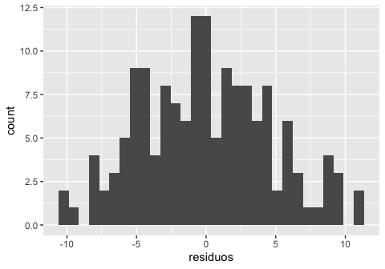

```r
# histograma para normalidade de resíduos

ggplot(aj.residuos, aes(x = residuos))+
  geom_histogram()
```

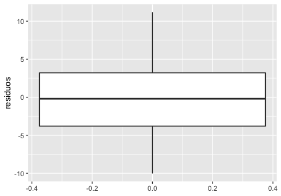

```r
# boxplot para normalidade de resíduos

ggplot(aj.residuos, aes(y=residuos))+
  geom_boxplot()
```

Nos gráficos, percebemos que há simetria entre as duas caudas do histograma e do boxplot, o que indica uma distribuição normal dos resíduos.

Outra maneira de olhar a normalidade é através de um *qqplot*, ou **gráfico q-q** / **gráfico quantil-quantil** em português. Esse tipo de gráfico compara os resíduos com uma distribuição hipotética, como a normal. Para fins práticos, precisamos saber que se os resíduos seguem uma distribuição normal, eles formam uma linha reta diagonal em um gráfico de dispersão. No código abaixo, `stat_qq` plota os resíduos e `stat_qq_line` indica a linha sobre a qual esses resíduos deveriam cair em caso de distribuição normal.

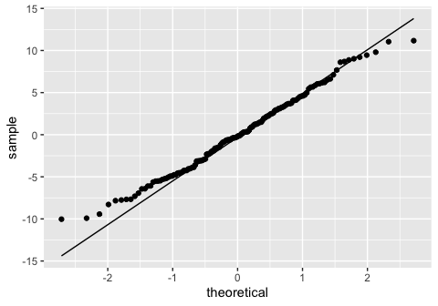

```r
# normalidade de resíduos: qqplot

ggplot(aj.residuos, aes(sample=residuos))+
  stat_qq()+
  stat_qq_line()
```

Vemos que os resíduos acompanham essa linha de forma razoavelmente consistente, o que permite atestar sua normalidade. Na **Figura 2.7** temos um exemplo de distribuição não normal.

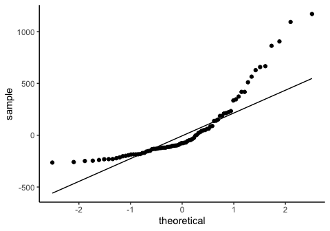

**Ausência de colinearidade**

Dizemos que dois efeitos fixos são colineares quando existe alguma correlação entre eles. Suponha que você acha que frequência de ocorrência e tamanho são duas variáveis que podem influenciar o tempo que uma pessoa leva para reconhecer uma palavra. Essas previsões fazem sentido: afinal, quanto menor a palavra, menos tempo eu levo para reconhecê-la; similarmente, eu também vou reconhecer com mais facilidade aquelas palavras que leio ou escuto mais. Uma vez que essa é minha previsão, eu poderia pensar no seguinte modelo:

> tempo ~ frequencia + tamanho

A questão (como os linguistas sabem) é que frequência e tamanho são fatores correlacionados. Palavras mais frequentes tendem a ser menores em um idioma, e palavras menos frequentes tendem a ser maiores. Desse modo, é difícil prever até que ponto cada um desses fatores contribui e como eles interagem. Se o seu modelo tiver colinearidade, vale a pena repensar seu desenho experimental ou pesquisar como resolver a questão de modo a ter resultados confiáveis.

**Independência**

Nas análises que fizemos aqui, cada observação veio de um participante (ou diamante) diferente: cada participante contribuiu com apenas uma medida de pitch, cada diamante com apenas uma medida de preço de venda. Podemos dizer que os dados são independentes porque todas as observações vieram de fontes diferentes, e cada fonte contribuiu com apenas uma observação.

No entanto, esse não é o cenário em muitas situações, principalmente quando trabalhando com desenhos experimentais. Para o experimento que procura relaciona pitch a idade, imagine que você gravou cada sujeito não apenas uma vez, mas cinco vezes. Você fez isso porque mais medidas por participante te darão uma estimativa mais confiável do pitch médio daquela pessoa. No entanto, agora há um problema. Cada participante tem suas próprias peculiaridades, e aquelas cinco medidas não são mais independentes umas das outras: elas todas se relacionam por terem sido produzidas pela mesma pessoa.

O modelo linear que aprendemos a construir nesta seção não é adequado para lidar com não-independência. Para isso, precisamos de uma nova classe de modelos, os **modelos lineares mistos**, que discutiremos na seção 3.

## 2.7 Prática: modelos lineares

Considerando o conjunto de dados `linguistas.csv` que vimos na seção anterior, construa um modelo linear que responda à seguinte pergunta:

> O peso de uma pessoa pode ser previsto por sua altura e idade?

Você deverá:

- Importar o conjunto de dados;
- Limpar os dados para considerar apenas linguistas da UFMG, Unicamp e UFRN, ignorando a observação que tem um tamanho de pé igual a 78
- Construir seu modelo linear e ver seus resultados;
- Analisar os resíduos para ver se não há violação de hipóteses;
- Escrever seus resultados como se fosse um artigo.

## REFERÊNCIAS

Winter, B. (2013). Linear models and linear mixed effects models in R with linguistic applications.  
arXiv:1308.5499. [http://arxiv.org/pdf/1308.5499.pdf]